# Assignment 2: Feature Engineering, Statistical Analysis and Machine Learning

Eunan Diamond (40293751)

# Introduction

## How to Use report

-Run each chunk in order every time you use this rmd file ## goals The goals for this assignment are to perform feature engineering, statistical analysis, Regression and Machine Learning on a data set of symbols of letters and non letters. Using r, I should develop code, and use my report to clearly show that I understand all the methods I used in each section to explain the results I get from my analysis.

# Section 1

I created the images using GIMP. After that I used read.delim to read them into R code, and then used then used R code to change the values with 0 (black pixels) to 1 and values with 255 (white pixels) to 0. I then created a matrix with the table we imported in, only from line 3 to last line as first 2 lines were headers, and the matrix has 18 rows and columns. I exported the matrix using write.table. I used separator as “,” and saved the file as .csv. I did this for all 140 of my images. # Section 2

```r
source("./section2_code.r")
```

For Section 2, I used one function to create all the features.Using one big function was easier as it made it easier to create the features vector in there and adding it to the matrix which would then be converted to csv file at the end. I converted the csv files to matrices so it would be easier to use for loops and if statements to attain the features I needed. I struggled with the eyes function, I worked around this by converting the 1’s into 0’s and 0’s into ones, this lead the areas of connected 0’s between 1’s using the 4 directions. I then took 2 away from the number of columns in the freq table, as 1 is for none and the other is for connected 0 (the converted 1’s). for my custom feature, I went for number with row with most black pixels as I thought they would help distinguish between symbols as faces would have more than a’s etc. Based on features data this has proved to be the case with the sad and smiley having big largest row of black pixel’s. And the ones expected to have less such as ! and a have a lot smaller, I believe this will help me distinguish between symbols in section 3.

```r
csvF<-read.csv(file ="40293751_features.csv" ,header = TRUE)
print(csvF)
```

```
##      label index nr_pix rows_with_1 cols_with_1 rows_with_3p cols_with_3p
## 1        a     1     35           1           0            8            7
## 2        a     2     33           2           0            8            6
## 3        a     3     53           0           0           10            7
## 4        a     4     31           1           0            8            6
## 5        a     5     62           0           0           11            8
## 6        a     6     76           0           0           12            9
## 7        a     7     80           0           0           12            9
## 8        a     8     62           0           0           10            8
## 9        b     1     25           7           0            2            2
## 10       b     2     36           6           0            6            4
## 11       b     3     50           0           0            8            6
## 12       b     4     69           0           0           12            8
## 13       b     5     23           5           0            0            2
## 14       b     6     46           0           0           10            6
```

[output cut: 408 more lines]

# Section 3

## Section 3.1

```
##  [1] ".GlobalEnv"         "package:psych"      "package:ggplot2"
##  [4] "package:data.table" "package:knitr"      "package:rstudioapi"
##  [7] "package:raster"     "package:sp"         "package:stats"
## [10] "package:graphics"   "package:grDevices"  "package:utils"
## [13] "package:datasets"   "package:methods"    "Autoloads"
## [16] "package:base"
```

```
## [1] "C:/Users/eunan/Documents/CSC2062 Assignment 2"
```

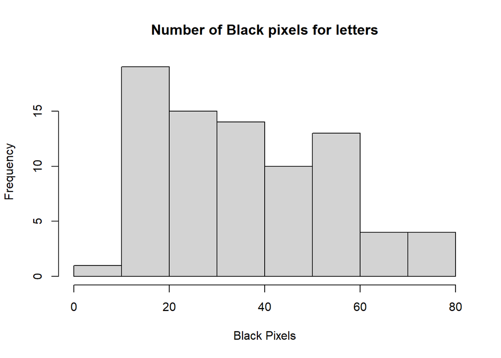

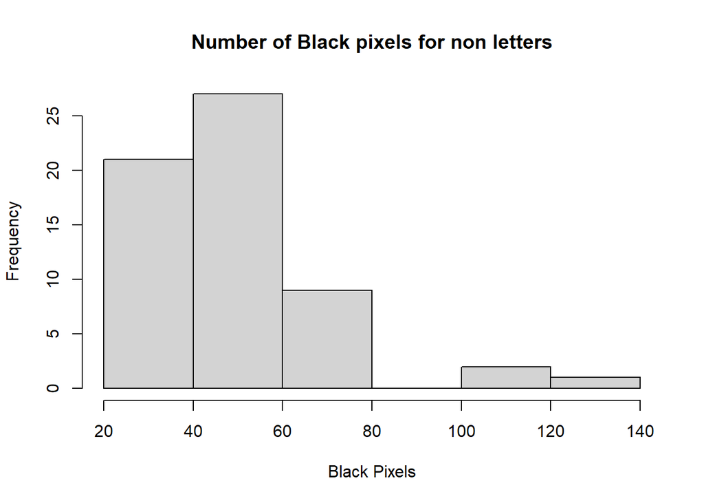

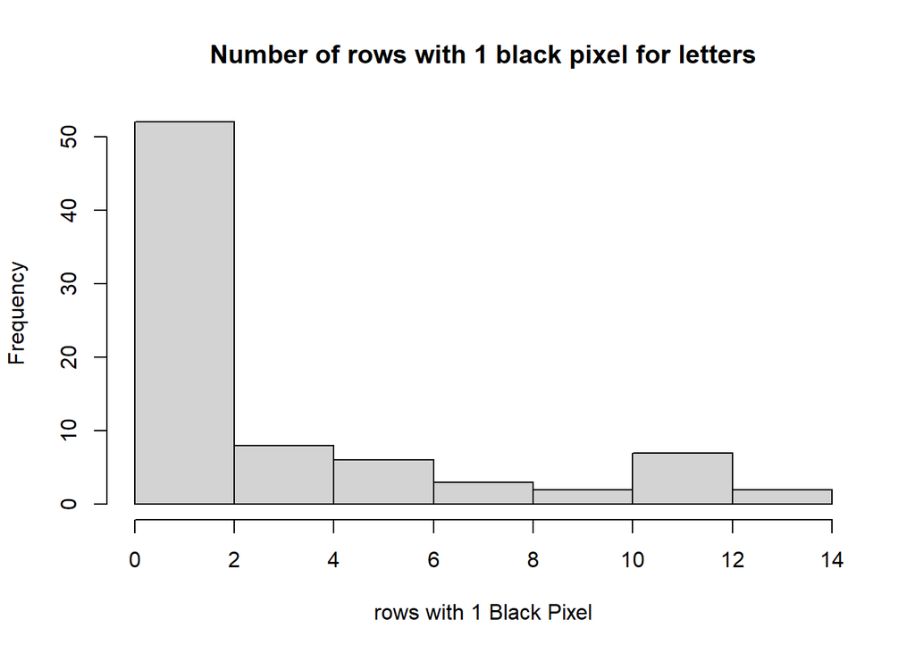

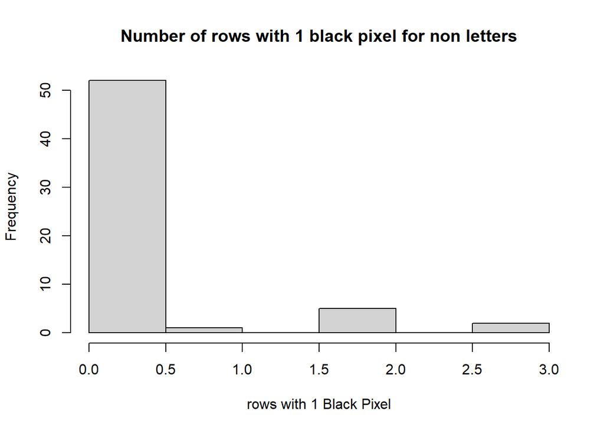

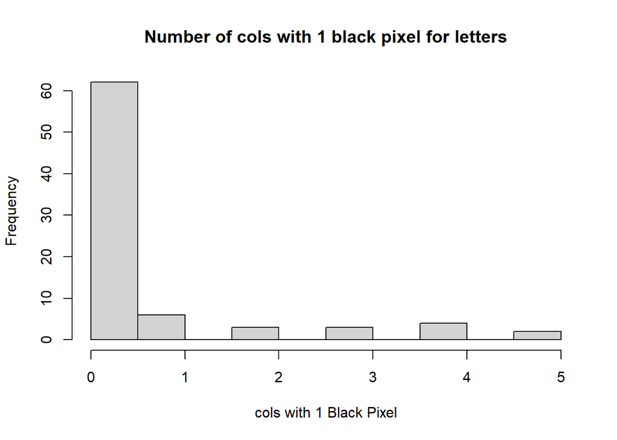

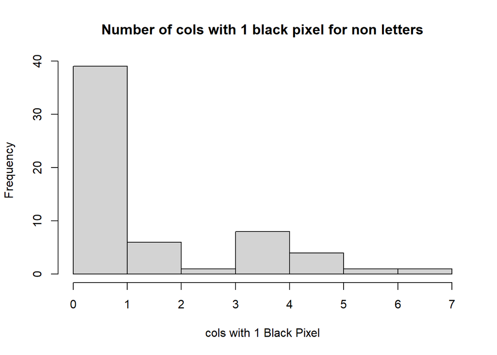

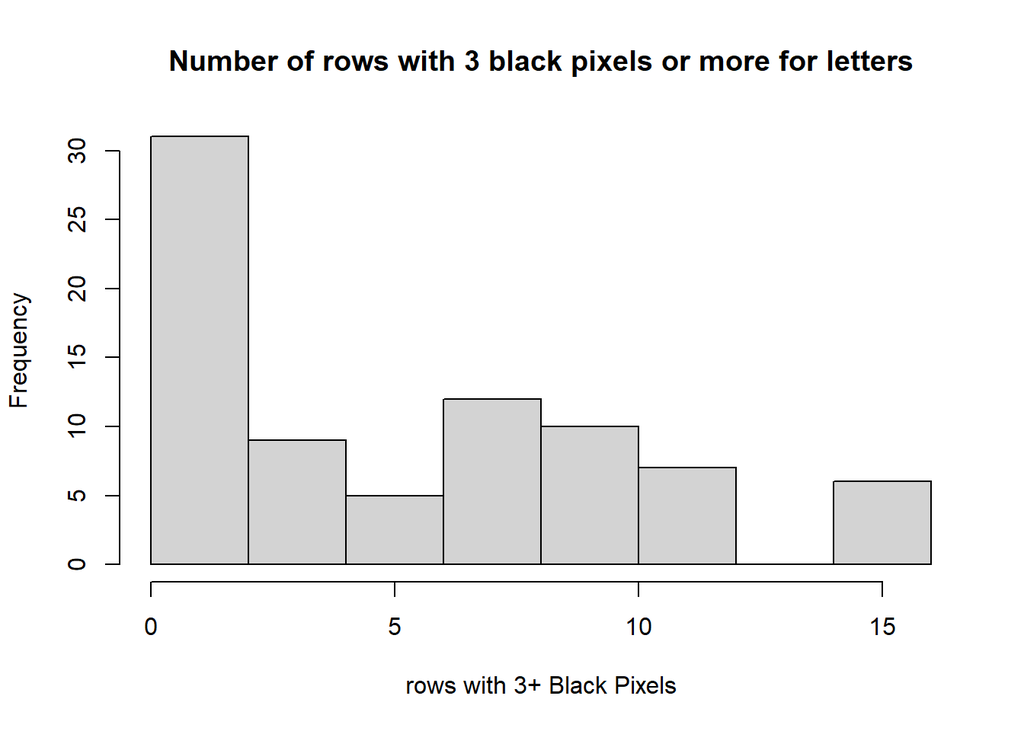

[figure not shown]

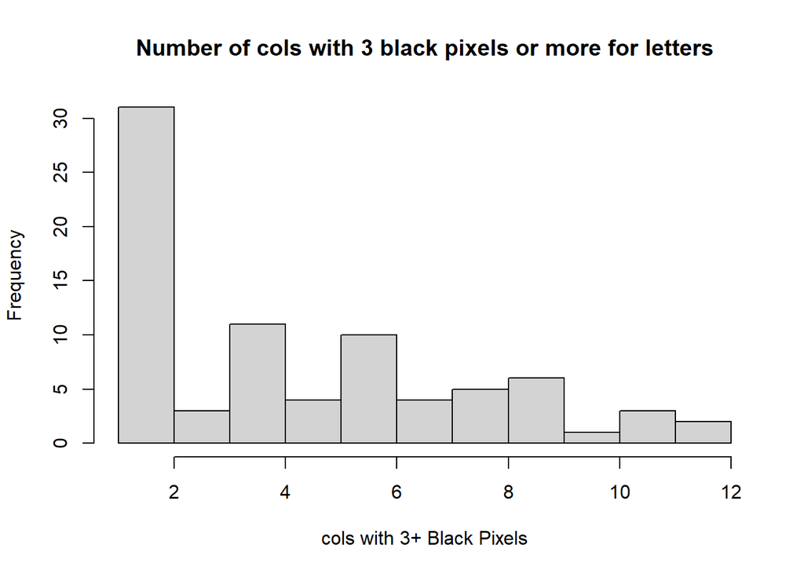

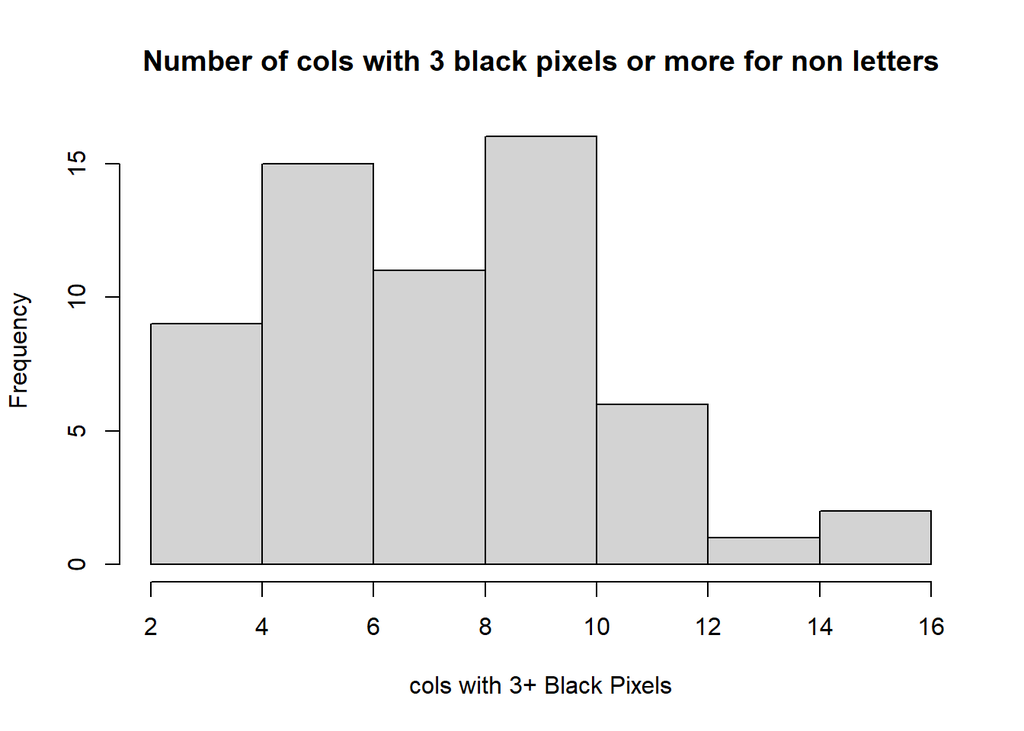

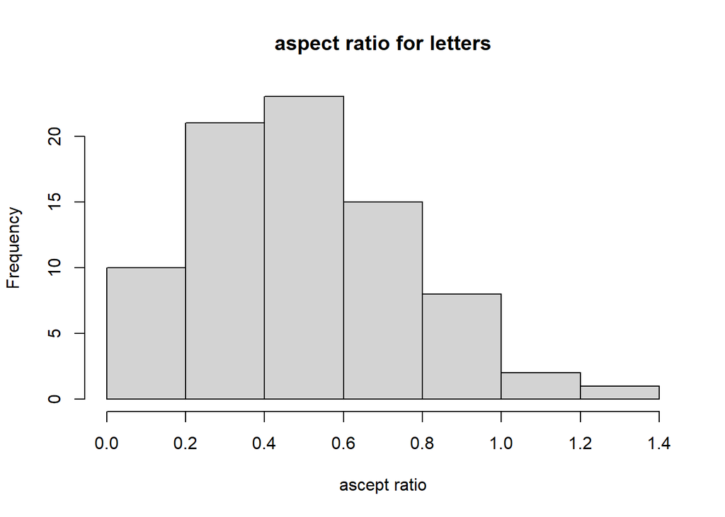

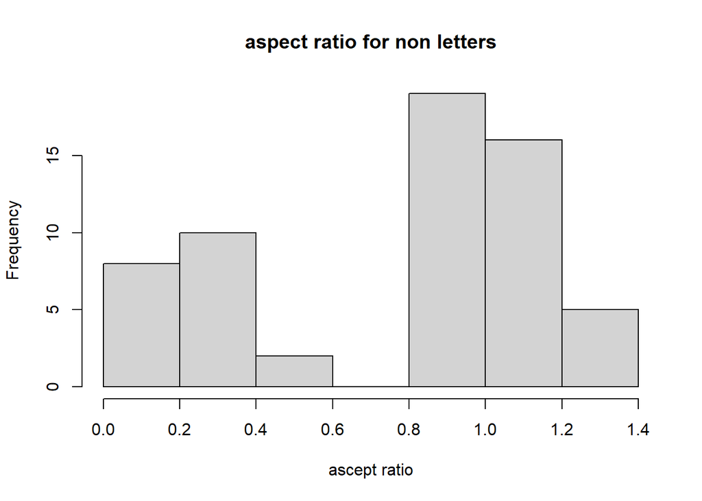

## Section 3.2

```
## [1] "Summary stats for no. of black pixels in letters"
##    Min. 1st Qu.  Median    Mean 3rd Qu.    Max.
##    9.00   21.50   33.00   36.15   51.00   80.00
## [1] "Summary stats for no. of black pixels in non letters"
##    Min. 1st Qu.  Median    Mean 3rd Qu.    Max.
##   24.00   38.00   49.00   51.55   58.50  133.00
## [1] "Summary stats for no. of rows with 1 black pixel in letters"
##    Min. 1st Qu.  Median    Mean 3rd Qu.    Max.
##   0.000   0.000   0.000   2.737   4.250  14.000
## [1] "Summary stats for no. of rows with 1 black pixel in non letters"
##    Min. 1st Qu.  Median    Mean 3rd Qu.    Max.
##  0.0000  0.0000  0.0000  0.2833  0.0000  3.0000
## [1] "Summary stats for no. of cols with 1 black pixel in letters"
##    Min. 1st Qu.  Median    Mean 3rd Qu.    Max.
##  0.0000  0.0000  0.0000  0.5875  0.0000  5.0000
## [1] "Summary stats for no. of cols with 1 black pixel in non letters"
##    Min. 1st Qu.  Median    Mean 3rd Qu.    Max.
##   0.000   0.000   0.000   1.383   2.250   7.000
## [1] "Summary stats for no. of rows with 3+ black pixel in letters"
##    Min. 1st Qu.  Median    Mean 3rd Qu.    Max.
##   0.000   2.000   4.500   5.713   9.000  16.000
## [1] "Summary stats for no. of rows with 3+ black pixel in letters"
##    Min. 1st Qu.  Median    Mean 3rd Qu.    Max.
##   0.000   5.000   7.000   7.583  10.000  17.000
## [1] "Summary stats for no. of cols with 3+ black pixel in letters"
##    Min. 1st Qu.  Median    Mean 3rd Qu.    Max.
##   1.000   2.000   4.000   4.588   7.000  12.000
## [1] "Summary stats for no. of cols with 3+ black pixel in nonletters"
##    Min. 1st Qu.  Median    Mean 3rd Qu.    Max.
##   2.000   5.000   8.000   7.733  10.000  16.000
## [1] "Summary stats for  ascept ratio for letters"
##    Min. 1st Qu.  Median    Mean 3rd Qu.    Max.
## 0.07143 0.33333 0.48333 0.52129 0.67857 1.25000
## [1] "Summary stats for  ascept ratio for nonletters"
##    Min. 1st Qu.  Median    Mean 3rd Qu.    Max.
## 0.05882 0.36364 1.00000 0.79514 1.09091 1.30000
## [1] "Summary stats for  all neighs with no black pixels for letters"
##    Min. 1st Qu.  Median    Mean 3rd Qu.    Max.
##       0       0       1       1       2       4
## [1] "Summary stats for  all neighs with no black pixels for nonletters"
```

[output cut: 41 more lines]

```
## [1] "Summary stats for  connected areas for nonletters"
##    Min. 1st Qu.  Median    Mean 3rd Qu.    Max.
##   2.000   2.000   4.000   3.333   4.000   4.000
## [1] "Summary stats for  eyes for letters"
##    Min. 1st Qu.  Median    Mean 3rd Qu.    Max.
##     0.0     0.0     0.0     0.4     1.0     1.0
## [1] "Summary stats for  eyes for nonletters"
##    Min. 1st Qu.  Median    Mean 3rd Qu.    Max.
##       0       0       0       0       0       0
## [1] "Summary stats for  widest row for letters"
##    Min. 1st Qu.  Median    Mean 3rd Qu.    Max.
##   1.000   3.000   5.000   5.312   7.000  13.000
## [1] "Summary stats for  widest row for nonletters"
##    Min. 1st Qu.  Median    Mean 3rd Qu.    Max.
##   2.000   5.000  10.000   9.033  12.000  16.000
```

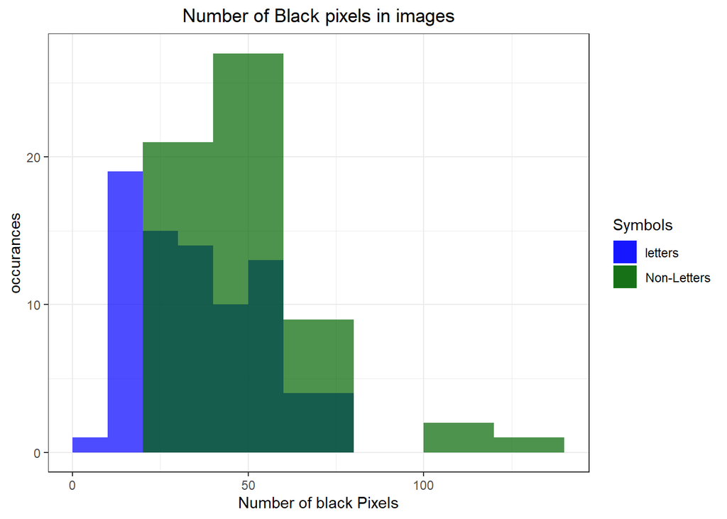

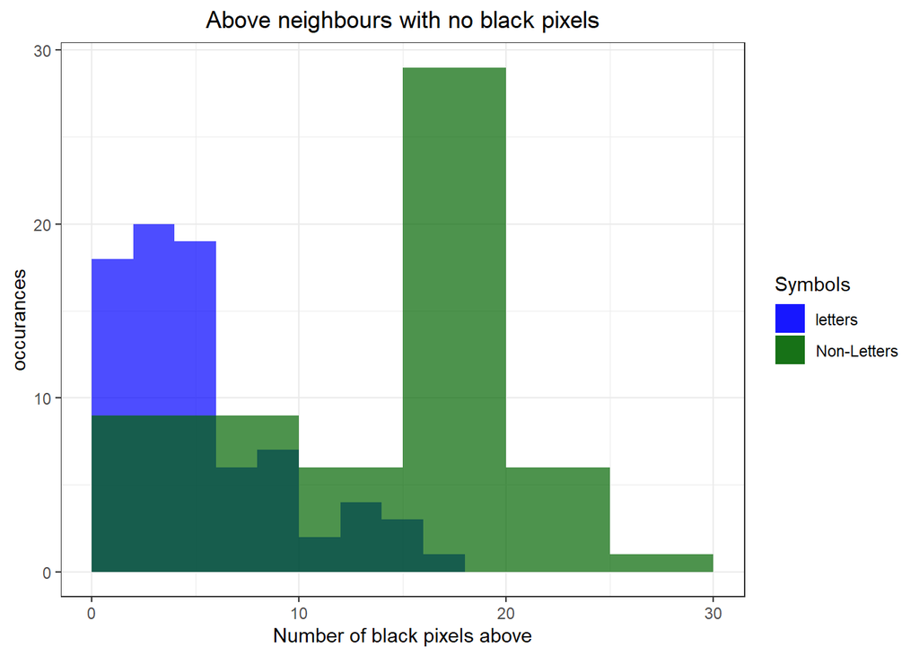

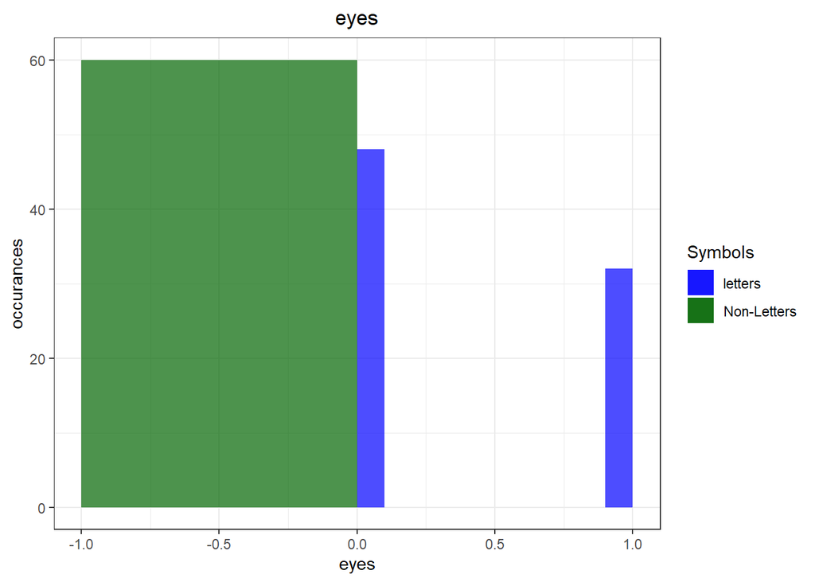

Above we can see the summary statistics for the features for letters and non letters. These will help me to see which features are most useful in distinguishing between letters and non letters.

For cols with 3+ black pixels, it is very similar to rows with the mean just a bit bigger and 4 difference between max and the same difference of 1st quadrant between rows with 3+ blc pixels.

With connected areas, non letters has the slightly bigger stats meaning it probably has more connected areas than letters. The difference is stats is not much as it isn’t expected for any one symbol to have a lot of different connected areas. This is similar to eyes but it is significant that non letters have no eyes, meaning eyes can be a big factor in telling if it is a letter or not because if it has an eye it will be a letter. With the final feature, widest row, non letters has bigger for everything, telling us if the wider the row the more like it is to be a non letter.

The 3 features I chose to represent in histograms:

1)number of black pixels because of the summary stats having such a wide difference with non letters having the higher values. it happens to be the case in the histogram, with letters (blue) having a high proportion in below 50. some of non letters fall below that range as well, but there is high number over 50, going the whole way to over 100.

2. No. Black pixels in above neighbour. I chose this as there was I big difference between the two in the summary stats and I think that will make it useful to distinguish between letters and non letters. And as expected from the summary stats the non letters (green) have far higher values. with letters having no image which has more than 20 pixels than have no pixels above when non letters have about 7 over 20 and up to 30, as well as having the majority over 15 pixels. this illustrate shows why it is a good feature to use.

3)Eyes. This is based off the fact that non letters has no eyes, . As see all the non letters are at 0, as well as about the 32 letter images which have an eye. No images has an more than 1 eye, so therefore if a image has an eye we know it is 100% a letter.Therefore this will be a key feature in finding a difference.

## Section 3.3

I will use statistical Analysis techniques to test if this which features are useful in telling difference between letter and non letters. After my analysis I will interpret my findings and validity my assumptions. I expect there will be features which will stand. I am making these assumptions based off the first two parts of section 3.

To start my analysis I calculated the skews for each feature for letters and non letters. I felt like this was a good stat to analysis as it will give me an idea of the distribution for letters and non letters for each feature.

```r
 skewStats<-read.csv(file ="SkewStats.csv" ,header = TRUE)
 print(skewStats)
```

```
##                                          letters Non.letters
##                                               NA          NA
## number of pixels                       0.4776982  1.71719691
## rows with 1 black pixel                1.2998730  2.44061601
## cols with 1 black pixel                2.1517397  1.09240056
## rows with 3 or more black pixels       0.4510288  0.47823148
## cols with 3 or more black pixels       0.5841886  0.34679509
## Aspect ratio                           0.5365861 -0.60642373
## neighbours with 1 black pixel          0.9651017  0.77004570
## no above neighbours with black pixels  1.1132016 -0.66083843
## no below neighbours with black pixels  1.4344206 -0.48729171
## no left neighbours with black pixels   0.3059638  0.17425679
## no right neighbours with black pixels -0.2858862  0.17425679
## no horiz neighbours with black pixels  0.7214405  1.00656173
## no vert neighbours with black pixels   2.3692287  0.80311748
## connected areas                        1.4719631 -0.68950297
## eyes                                   0.4006176          NA
## custom                                 0.6048080 -0.08176291
```

As shown above is the table of the skews for letters and non letters for each feature. I believe if the skews differ a lot between letters and non letters it could be a factor in telling if the feature can be used to tell difference between letters hand non letters.

To start number of black pixels skew differs between letters and non letters. letters is only moderately skewed with 0.4 whereas non letters is highly skewed with 1.7, this shows the distribution shape is massively difference. This supports our summary stats as this was one of the features I had suggested that could be used to differ between the two.

With The 1 black pixel in cols and rows there is a big difference in skews again. With rows having 1.2 difference, both having a highly skewed, this tells us that they both have a high count in the smaller values, such as 0, which was proven to be the case in 3.1, Cols is very similar.

for 3+ rows and cols for both letters and non letters the skews are very similar with both of them having approximately symmetric skew with around 0.5. Therefore these features do not differ much and would not be a good measure to find difference based on their skews.

for 1 black pixel neighbour it supports the summary stats where the they were very similar between letters and non letters.

for left and right neighbours no black pixels, they are very similar with skews in a range of 0.3(letters) and 0.17(non letters) for left and -0.28(letters) and 0.17(non letters). Therefore as the same as summary stats these are suggested.

For horiz neighbours there is only 0.3 between skewness meaning there distribution is similar therefore it can not be used. The same can not be said for vert.

For eyes as expected based off summary stats, non letters will have no skewness because all values are 0, while letters are 0.4, this shown on the summary stats. The fact it has no Skewness, makes it a key feature in telling the difference as stated in the summary stats section

In next part of my analysis I will use box plots and T-tests to see if the analysis I have shown before with the skews and summary stats are proven to be correct.

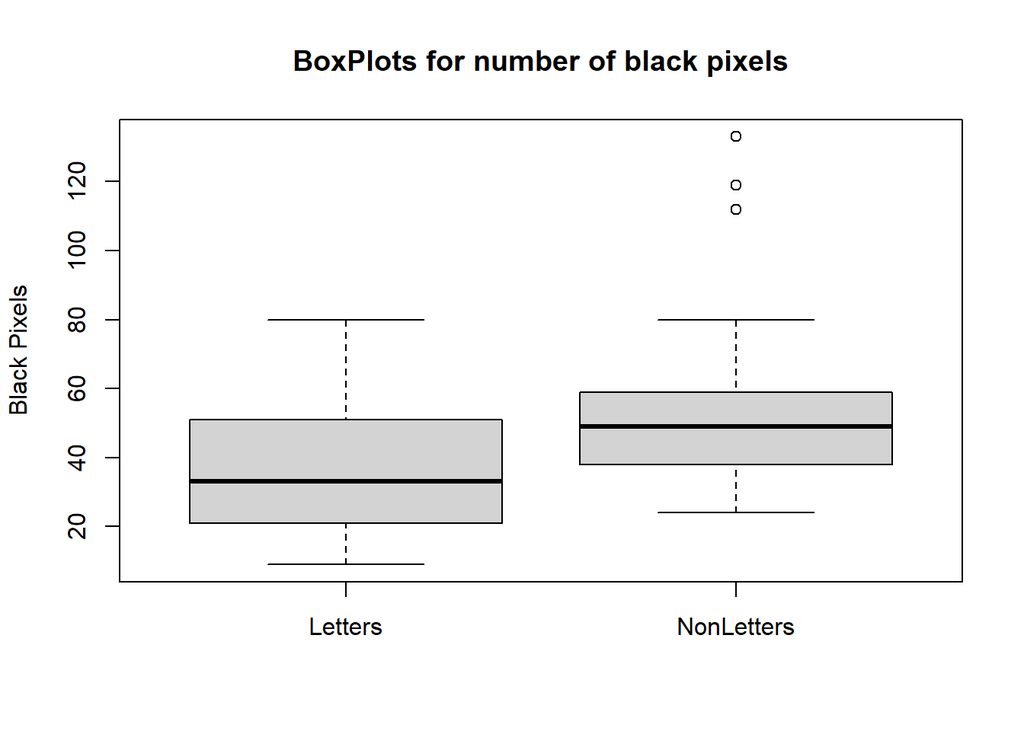

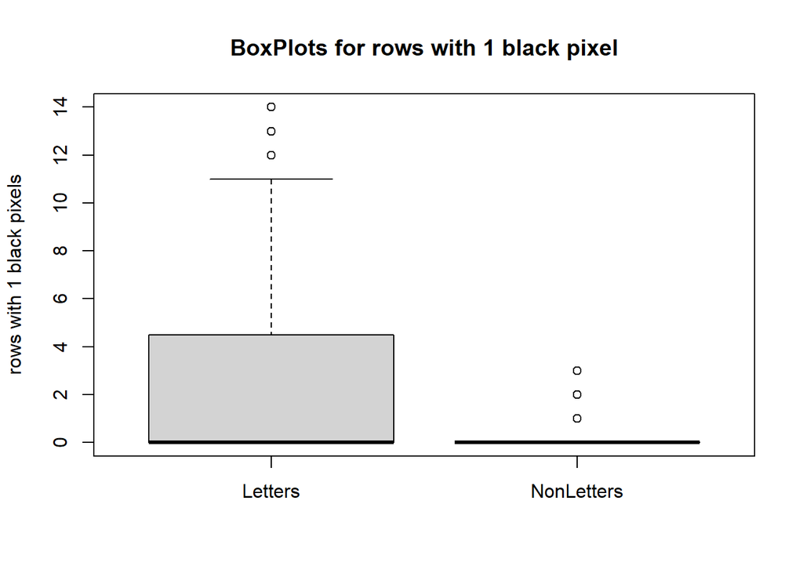

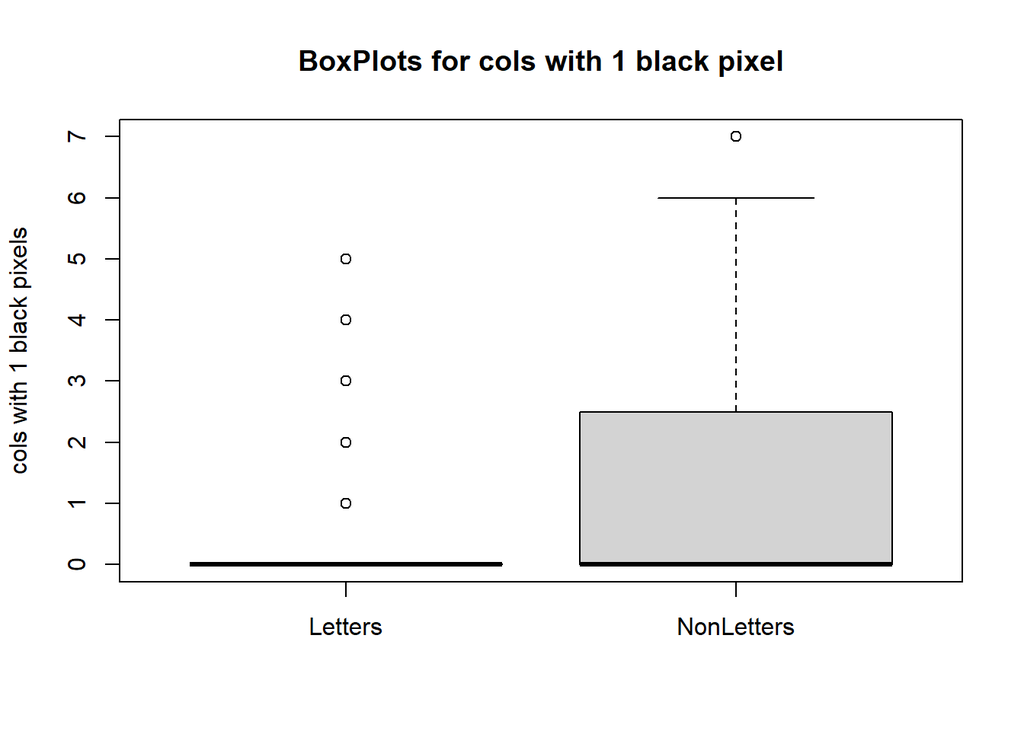

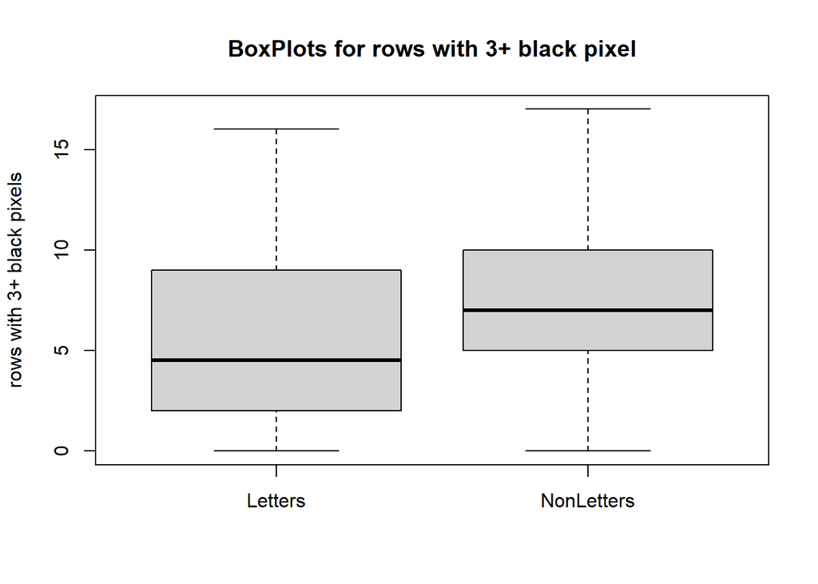

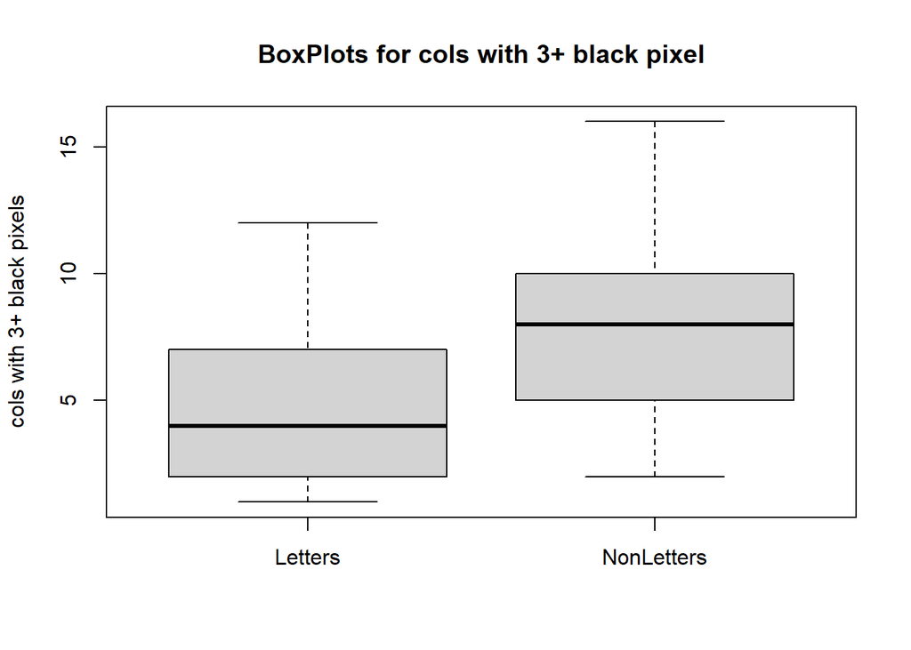

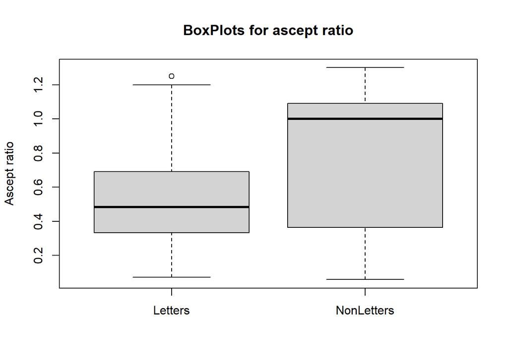

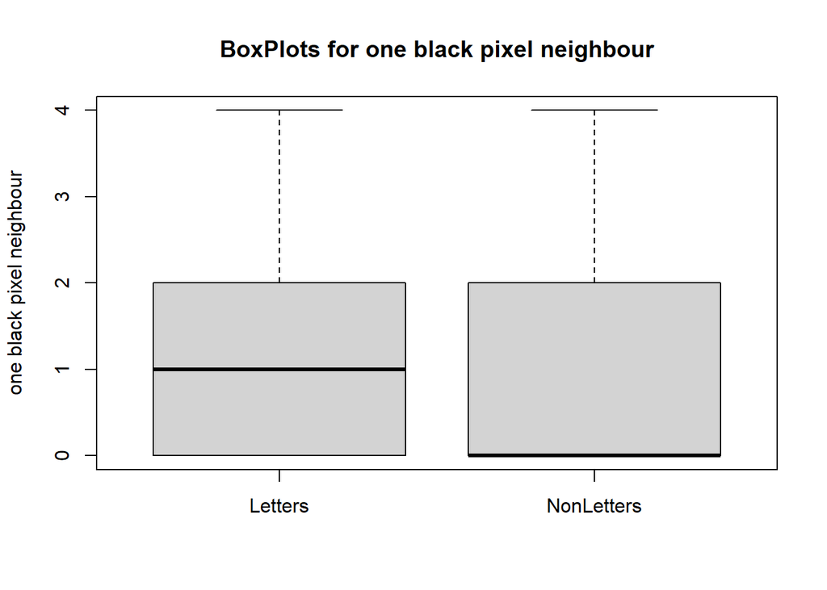

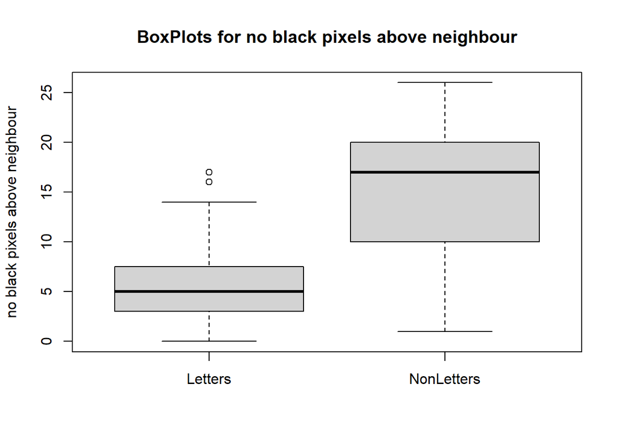

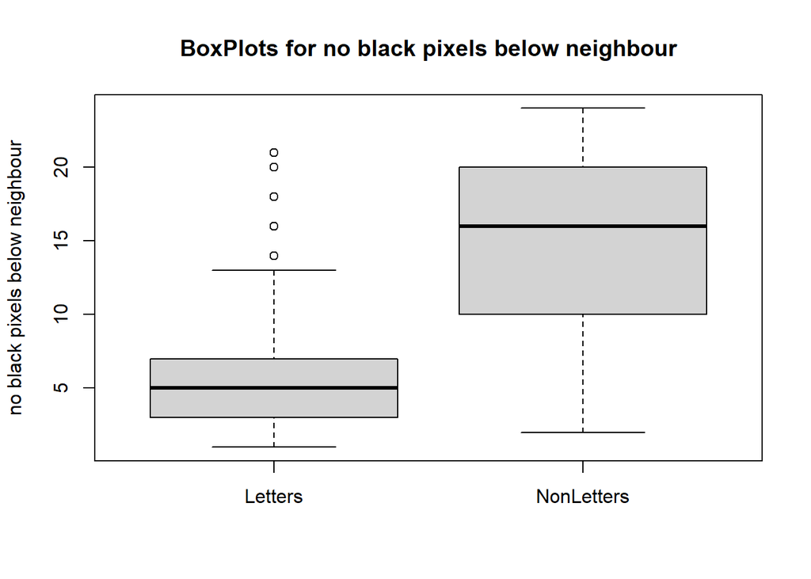

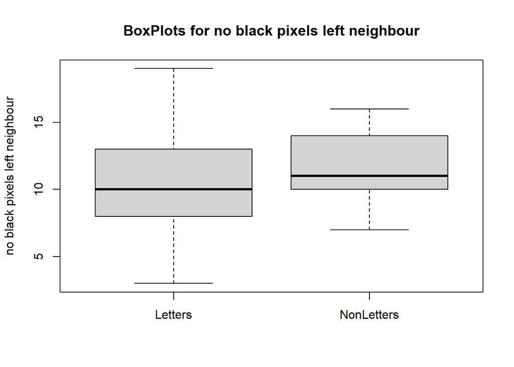

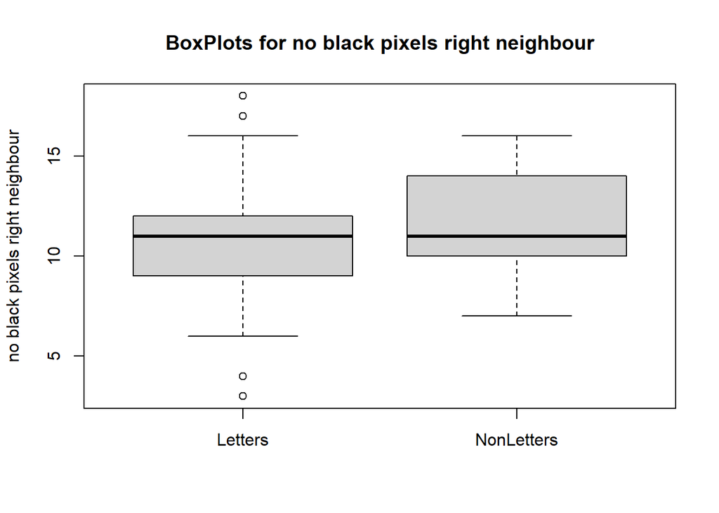

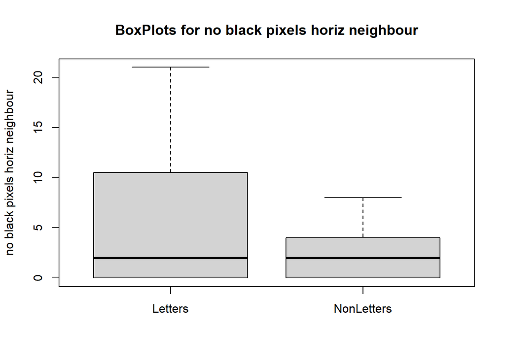

[4 more figures not shown]

```
##
##  Welch Two Sample t-test
##
## data:  csvF[1:80, 3] and csvF[81:140, 3]
## t = -4.5153, df = 113.99, p-value = 1.55e-05
## alternative hypothesis: true difference in means is not equal to 0
## 95 percent confidence interval:
##  -22.156448  -8.643552
## sample estimates:
## mean of x mean of y
##     36.15     51.55
##
##
##  Welch Two Sample t-test
##
## data:  csvF[1:80, 4] and csvF[81:140, 4]
## t = 5.3288, df = 86.453, p-value = 7.763e-07
## alternative hypothesis: true difference in means is not equal to 0
## 95 percent confidence interval:
##  1.538691 3.369643
## sample estimates:
## mean of x mean of y
## 2.7375000 0.2833333
##
##
##  Welch Two Sample t-test
##
## data:  csvF[1:80, 5] and csvF[81:140, 5]
## t = -2.699, df = 94.909, p-value = 0.008233
## alternative hypothesis: true difference in means is not equal to 0
## 95 percent confidence interval:
##  -1.3812125 -0.2104542
## sample estimates:
## mean of x mean of y
##  0.587500  1.383333
##
##
##  Welch Two Sample t-test
##
## data:  csvF[1:80, 6] and csvF[81:140, 6]
```

[output cut: 136 more lines]

```
## sample estimates:
## mean of x mean of y
##       0.4       0.0
##
##
##  Welch Two Sample t-test
##
## data:  csvF[1:80, 18] and csvF[81:140, 18]
## t = -6.3872, df = 101.81, p-value = 5.115e-09
## alternative hypothesis: true difference in means is not equal to 0
## 95 percent confidence interval:
##  -4.876327 -2.565340
## sample estimates:
## mean of x mean of y
##  5.312500  9.033333
```

Above you can see the boxplots, which I have decided to use to further validate my early findings. It graphically shows which features differ for letters and non letters, such as first feature number of black pixels. Which with my early findings I found to be be a feature that could be used to differ between letters and non letters, these box plots shows the difference in ranges, and they may not be so different as first expected with only a few massive valeus for non letters which may of helped raised the mean, but the overall range isn’t too different to different between the two. and With eyes, this shows graphically what the skews showed, that all non letters have no eyes, as everything is 0 for it in the boxplot, this is not the same for letters, therefore it shows us what we assumed previously.

I think these box plots has helped to further prove the difference or similarities between letters and non letters for each feature. As mean is not included I will now use T-tests to test the mean between letters and non letters for each feature and come to a conclusion which features are most useful in terms of telling the difference between the letters and non letters. I will use welch t-tests as the populations are not the same size to do paired t tests.

T-tests are good for statistical analyses as it’s used to compare the means of two groups, which is perfect for the analysis we want to perform. There is null hypothesis and alternative hypothesis. The null hypothesis is the difference in group means is zero and the alternative hypothesis is the difference in group means is different from zero. It is used to test if there is a difference between two groups. It also calculates a p value. A p value is the probability that the results from your data occurred by chance. They range from 0% to 1% and written in decimal. If the p value is less than 0.05 it is strongly significant. It indicates strong evidence against the null hypothesis, as there is less than a 5% probability the null is correct (and the results are random). Therefore, we reject the null hypothesis, and accept the alternative hypothesis. A p-value higher than 0.05 is not statistically significant and indicates strong evidence for the null hypothesis. Therefore the p value can be used to help us verify our assumptions, As you can see from the t-tests the p values are behind 5% for all them except for feature 7, 1 black pixel neighbour with 8.687% and feature 13 vert no black pixel neighbour with 8.8%. This tells us that there is a significant difference between letters and non letters for the rest of the features. The t-test shows differences in means which tell us that there is a difference between letters and non letters. The biggest difference in mean is 15.4 for feature 1, which backs up our earlier summary which suggested that it would be a good feature to tell difference. Feature 8 no_neigh_above has a mean difference of 8.95 between letters and non letters which backs up earlier analysis which suggested it was a good feature to tell difference, the same can be said for no_neigh_below, which difference in mean is about 8.3. As you can see above the means differ slightly between other features which have a signicant difference between means but based off the t tests as well as the box plots and skews I believe these 3 features are the best suited to tell the difference between letters and non letters as well as eyes because it’s all 0’s for non letters. ## Section 3.4

```r
 cors<-read.csv(file ="correlations.csv" ,header = TRUE)
 print(cors)
```

```
##                       nr_pix rows_with_1 cols_with_1 rows_with_3p cols_with_3p
## nr_pix           1.000000000 -0.56077283 -0.31520252   0.79119224   0.65531196
## rows_with_1     -0.560772832  1.00000000  0.20703546  -0.51041636  -0.56455712
## cols_with_1     -0.315202522  0.20703546  1.00000000  -0.35075351  -0.05731039
## rows_with_3p     0.791192236 -0.51041636 -0.35075351   1.00000000   0.40239633
## cols_with_3p     0.655311961 -0.56455712 -0.05731039   0.40239633   1.00000000
## aspect_ratio     0.269571627 -0.37857492  0.32782637   0.04574902   0.79054621
## neigh_1         -0.527050327  0.52358786  0.62621567  -0.51484769  -0.36605708
## no_neigh_above   0.389727091 -0.44101965  0.23872825   0.10674969   0.82412908
## no_neigh_below   0.424176500 -0.45358925  0.19011901   0.14678716   0.85109076
## no_neigh_left    0.231560393 -0.03236569 -0.02514277   0.21728960  -0.15465860
## no_neigh_right   0.280120977 -0.05539138 -0.07145362   0.32795443  -0.13685876
## no_neigh_horiz  -0.553150627  0.74253454  0.31558577  -0.51460288  -0.41145479
## no_neigh_vert   -0.358053170  0.12313225  0.49619393  -0.37686593   0.08633827
## connected_areas  0.145949593 -0.27010351  0.38230658  -0.09012643   0.48762501
## eyes            -0.001636818 -0.01002933 -0.28344259   0.05213987   0.07174159
## custom           0.501925418 -0.47140542  0.19978182   0.22321649   0.89063760
##                 aspect_ratio      neigh_1 no_neigh_above no_neigh_below
## nr_pix            0.26957163 -0.527050327      0.3897271     0.42417650
## rows_with_1      -0.37857492  0.523587860     -0.4410196    -0.45358925
## cols_with_1       0.32782637  0.626215671      0.2387283     0.19011901
## rows_with_3p      0.04574902 -0.514847695      0.1067497     0.14678716
## cols_with_3p      0.79054621 -0.366057083      0.8241291     0.85109076
## aspect_ratio      1.00000000  0.013853963      0.8742152     0.87366851
## neigh_1           0.01385396  1.000000000     -0.0576068    -0.09989739
## no_neigh_above    0.87421524 -0.057606799      1.0000000     0.97331030
## no_neigh_below    0.87366851 -0.099897385      0.9733103     1.00000000
## no_neigh_left    -0.32708801 -0.004245014     -0.1976094    -0.21184056
## no_neigh_right   -0.38154687 -0.061983461     -0.2231341    -0.23449750
## no_neigh_horiz   -0.14660995  0.549348544     -0.3246704    -0.34165713
## no_neigh_vert     0.40274009  0.411588829      0.2538882     0.24009345
## connected_areas   0.56714810  0.166609793      0.7772364     0.74155466
## eyes             -0.06090808 -0.241570293     -0.2559332    -0.18827842
## custom            0.90665137 -0.132159742      0.9054797     0.91623642
##                 no_neigh_left no_neigh_right no_neigh_horiz no_neigh_vert
## nr_pix            0.231560393    0.280120977   -0.553150627   -0.35805317
## rows_with_1      -0.032365688   -0.055391384    0.742534541    0.12313225
## cols_with_1      -0.025142766   -0.071453618    0.315585769    0.49619393
## rows_with_3p      0.217289604    0.327954431   -0.514602884   -0.37686593
## cols_with_3p     -0.154658599   -0.136858763   -0.411454790    0.08633827
```

[output cut: 13 more lines]

```
## rows_with_1         -0.27010351 -0.010029326 -0.47140542
## cols_with_1          0.38230658 -0.283442586  0.19978182
## rows_with_3p        -0.09012643  0.052139865  0.22321649
## cols_with_3p         0.48762501  0.071741592  0.89063760
## aspect_ratio         0.56714810 -0.060908078  0.90665137
## neigh_1              0.16660979 -0.241570293 -0.13215974
## no_neigh_above       0.77723638 -0.255933209  0.90547975
## no_neigh_below       0.74155466 -0.188278424  0.91623642
## no_neigh_left        0.03649128 -0.218656912 -0.17978622
## no_neigh_right       0.03132800 -0.164471996 -0.21113030
## no_neigh_horiz      -0.23373407  0.216314783 -0.29790626
## no_neigh_vert        0.15021337  0.177289447  0.22938021
## connected_areas      1.00000000 -0.481481481  0.60884042
## eyes                -0.48148148  1.000000000 -0.09157427
## custom               0.60884042 -0.091574267  1.00000000
```

For this part, I used the cor function in r, which calculates a value between -1 and 1, values close to -1 mean a negative correlation between two features and a value near 1 means a positive correlation between the two features.

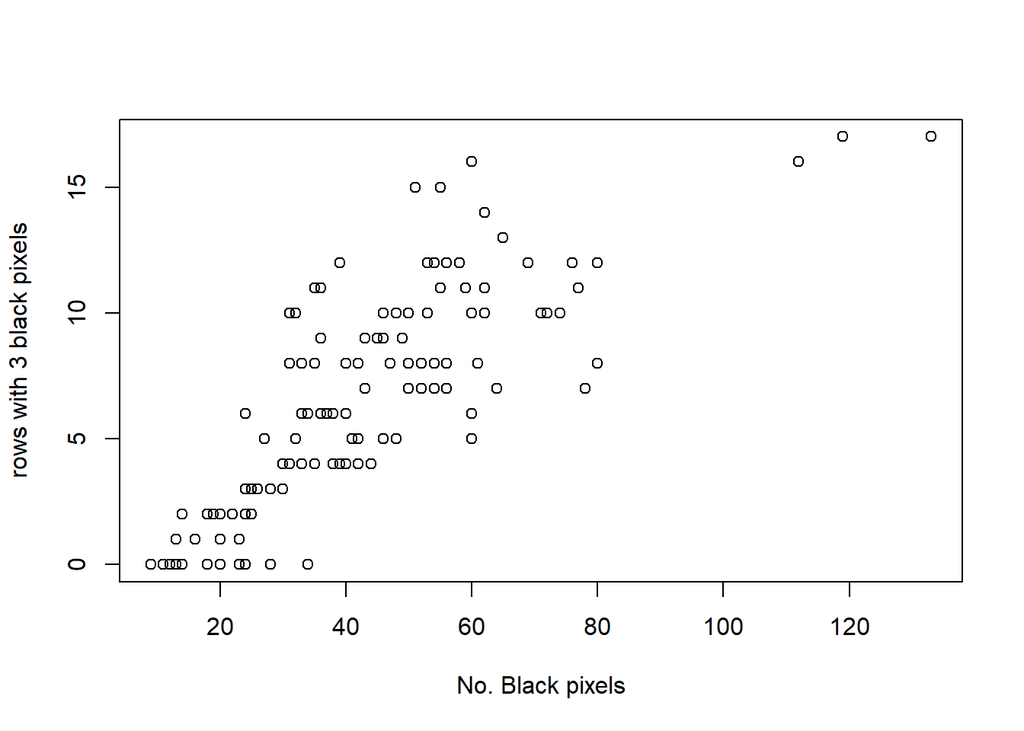

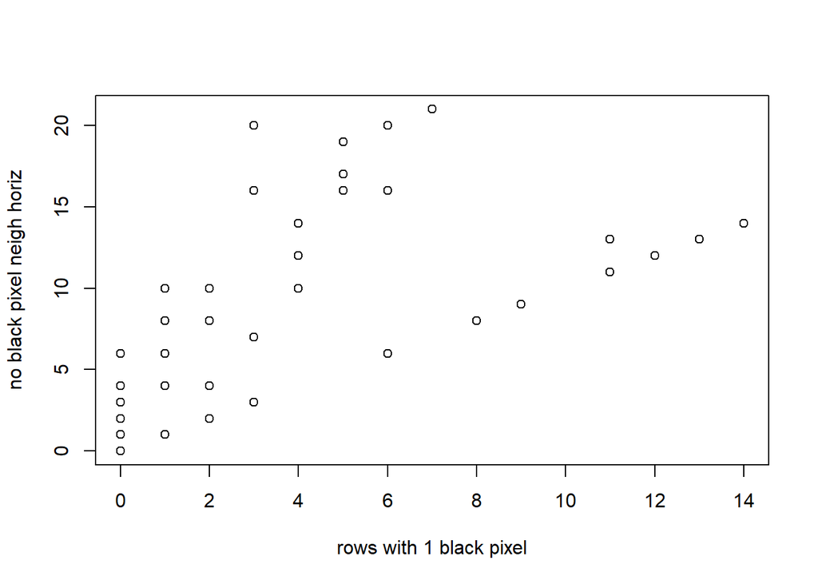

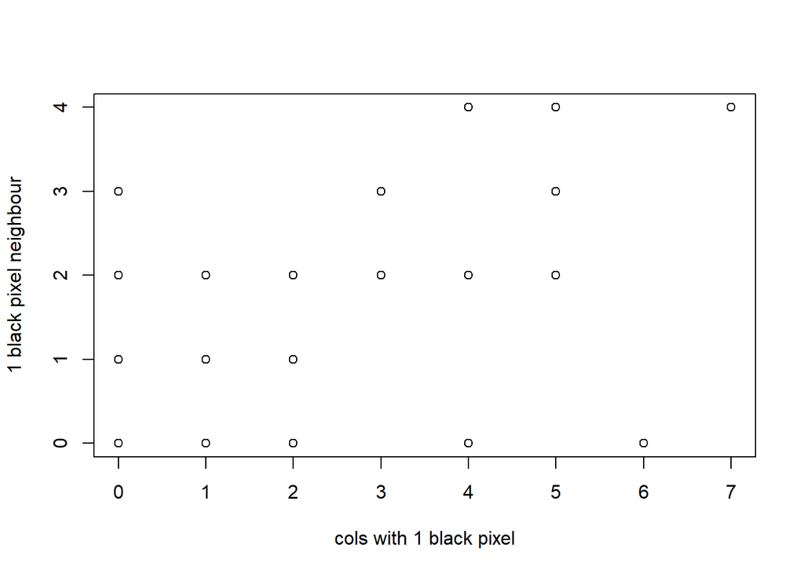

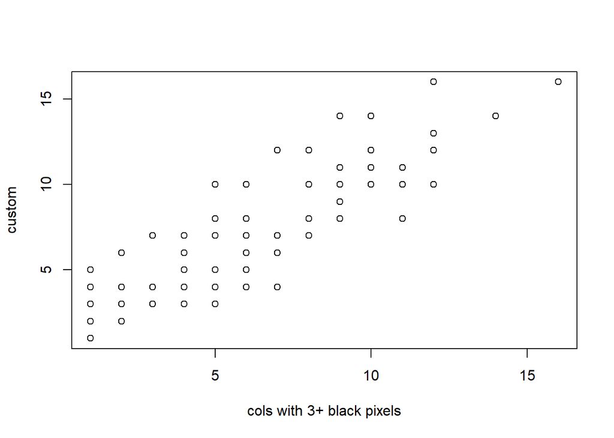